# Project 2 - Gradient Boosting Trees

Willie Langenberg

12/8/2021

```r
url <- "../Data/data.txt"
data_url <- "../Data/spambase/spambase.data"
names_url <- "../Data/spambase/spambase.names"
```

```r
df <- read_table(url, col_names = FALSE)
#df2 <- read_delim(url, ' ', col_names = FALSE)
```

## Task 1

### a)

I decided to use the function gbm from the gbm package in R. The package delivers functions with implementations of various gradient boosting models extended from Freund and Shapire’s AdaBoost Algorithm (1997) and J. Friedman’s gradient boosting machine (2001).

First of all you can specify the formula and data as with any other statistical modelling function in R. Formula is where you tell how we want to model our data, so which column to use as response variable and which are the predictors. Further, since we are dealing with a binary classification problem, I will choose bernoulli as distribution for the (gbm) function. Also I will specify that we will use $1500$ trees by setting the argument n.trees to $1500$. I want each tree to consist of only a stump, specified by setting the interaction.depth to $1$. For each iteration of the boosting algorithm I want the model to learn slowly since we are using quite a lot of trees and this is done by changing the shrinkage argument. I set it to the value $0.01$.

You are also able to specify arguments such as weights, for the fitting process, but I leave this as default (empty). Further n.minobsinnode specify the minimum amount of observation in a terminal node, I set this as zero because I do not have a preference about this. Then there is var.monotone to specify if we know that the predictors have any monotone relationship with the response variable, which I have no knowledge about, hence I leave it as default (NULL). Also, we have the option to specify bag.fraction to include some randomness to the model in the way of only using a fraction of the data to train next tree in the algorithm, I leave this at default 0.5 since I do not really have a preference about this either. Lastly we can specify if we want to only train on a fraction of the data, and save some for estimating the loss function on out-of-sample data, I will not do this. Also, we can specify cross validation folds (default = 0), stratify classes (default = NULL), choose how many CPU cores (I use 8) to use and choose if we want to print performance outputs (verbose, with default = FALSE).

### c)

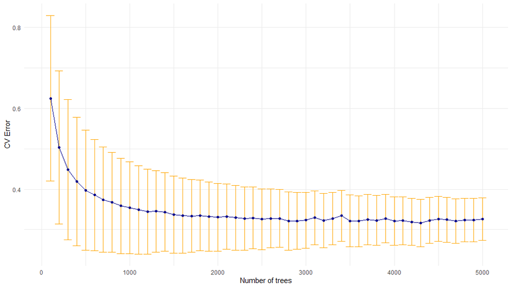

### d)

- Discuss how the performance of boosting trees varies with different values of m and M, draw connections to the concept of bias-variance tradeoff.

## Task 2

### a)

- Show that the gradient of the deviance as loss function is given by the expression in the last row of the table